# Quality Control

# PCA Plot

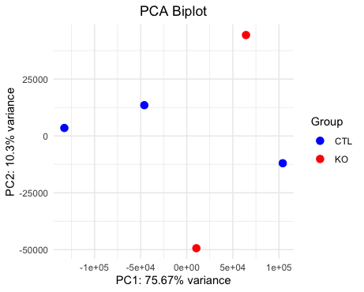

```python
from IPython.display import Image
Image(filename='results/PCAbiplot.png')
```

# Differential Expression

```python
After performing DE analysis, choose an appropriate FDR threshold to subset your DE results.
How many genes are significant at your chosen statistical threshold?
There are 68 differentially expressed genes at an FDR threshold of 0.01.
```

# A tibble: 15,433 × 8 geneids baseMean log2FoldChange lfcSE stat pvalue padj genenames 1 ENSMUSG00000008489.19 642. -1.10 0.123 -8.94 3.81e-19 3.94e-15 Elavl2 2 ENSMUSG00000035783.10 1281. 0.762 0.0948 8.04 8.81e-16 4.56e-12 Acta2 3 ENSMUSG00000020581.12 3148. 0.887 0.119 7.43 1.12e-13 3.85e-10 Agr2 4 ENSMUSG00000068923.15 268. -0.965 0.147 -6.57 4.98e-11 1.03e- 7 Syt11 5 ENSMUSG00000030265.15 1261. 0.982 0.149 6.60 4.18e-11 1.03e- 7 Kras 6 ENSMUSG00000034701.10 601. -0.899 0.141 -6.37 1.92e-10 3.30e- 7 Neurod1 7 ENSMUSG00000051747.16 534. -0.783 0.124 -6.33 2.45e-10 3.62e- 7 Ttn 8 ENSMUSG00000068154.6 1021. -0.953 0.153 -6.24 4.48e-10 5.79e- 7 Insm1 9 ENSMUSG00000031626.19 186. -1.11 0.185 -6.01 1.87e- 9 2.14e- 6 Sorbs2 10 ENSMUSG00000040752.17 45.7 1.99 0.336 5.91 3.37e- 9 3.49e- 6 Myh6 # ℹ 15,423 more rows

# Histogram of log2FoldChanges for DE genes

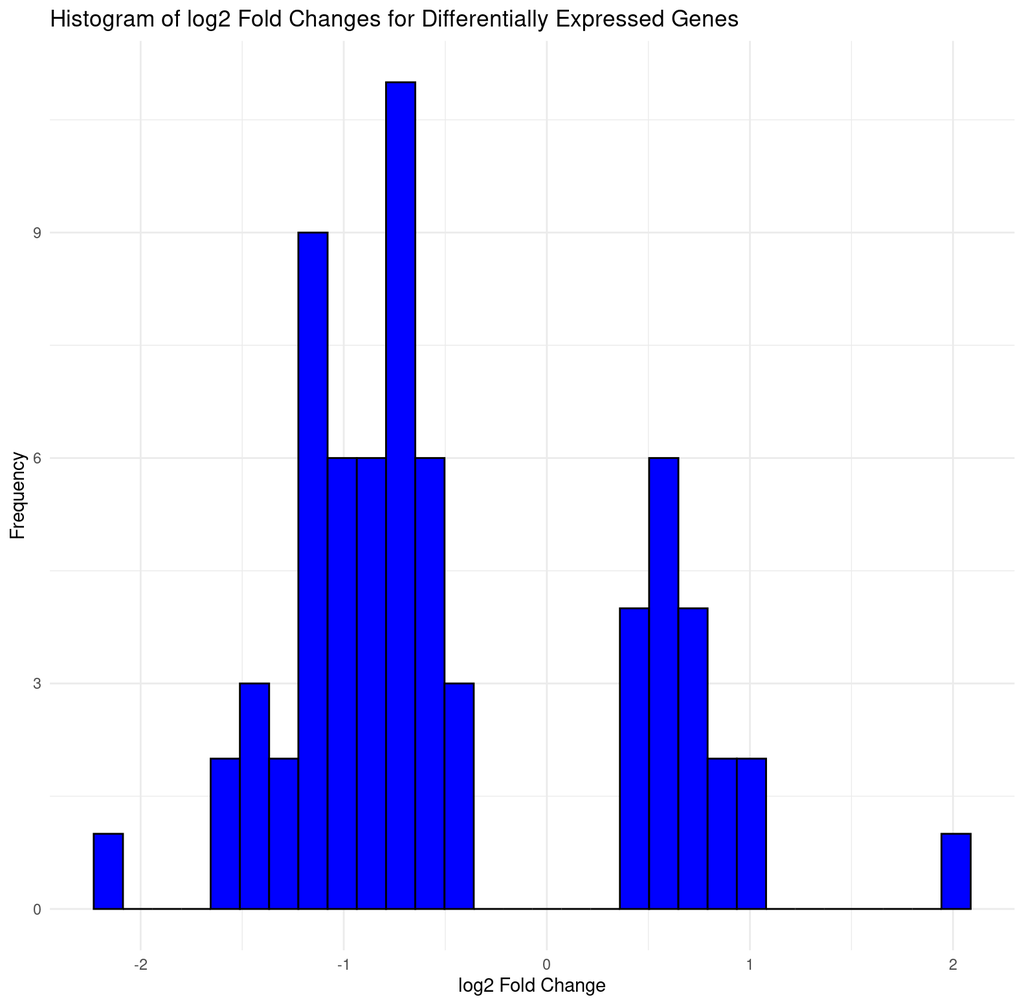

```python
from IPython.display import Image
Image(filename='results/histogram.png')
```

# Volcano Plot of DE genes

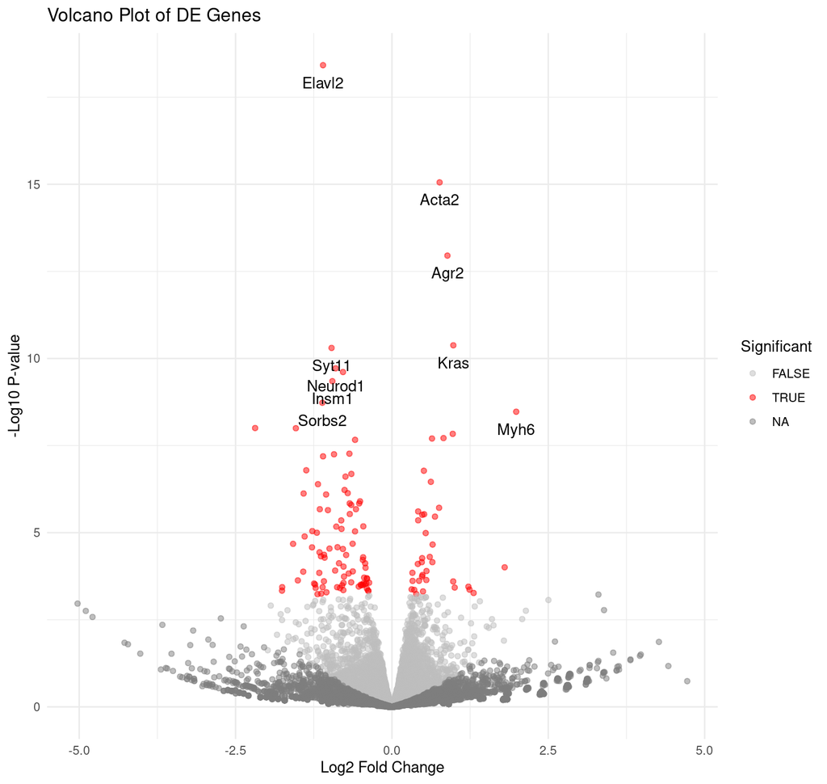

```python
from IPython.display import Image
Image(filename='results/volcano.png')
```